```python
# data analysis
import numpy as np
import pandas as pd

# data visualization
import matplotlib.pyplot as plt
import seaborn as sns

#prophet time series
from fbprophet import Prophet
```

# Learn By Building - Time Series Forecasting using Prophet in Python

Sebelumnya anda sudah mempelajari metode membangun model time series untuk melakukan forecasting total quantity penjualan dari `shop_id = 31`. Pada LBB kali ini, silahkan buat sebuah pemodelan untuk melakukan forecasting **total revenue** pada **`shop_id = 25`**

## Data Cleansing and Preprocessing

**1. Read Dataframe**

```python
# code here
sales = pd.read_csv('data_input/sales_train.csv')
sales.head()
```

|  | date | date_block_num | shop_id | item_id | item_price | item_cnt_day |
| --- | --- | --- | --- | --- | --- | --- |
| 0 | 02.01.2013 | 0 | 59 | 22154 | 999.00 | 1.0 |
| 1 | 03.01.2013 | 0 | 25 | 2552 | 899.00 | 1.0 |
| 2 | 05.01.2013 | 0 | 25 | 2552 | 899.00 | -1.0 |
| 3 | 06.01.2013 | 0 | 25 | 2554 | 1709.05 | 1.0 |
| 4 | 15.01.2013 | 0 | 25 | 2555 | 1099.00 | 1.0 |

**2. Transform Data Types**

```python
# code here
sales['date'] = pd.to_datetime(sales['date'], dayfirst=True)
sales.sort_values('date',inplace=True)
```

**3. Create colums `total_revenue` based on `item_price * item_cnt_day`**

```python
# code here
sales['total_revenue'] = sales['item_price'] * sales['item_cnt_day']
sales.head()
```

|  | date | date_block_num | shop_id | item_id | item_price | item_cnt_day | total_revenue |
| --- | --- | --- | --- | --- | --- | --- | --- |
| 49800 | 2013-01-01 | 0 | 18 | 5823 | 2500.0 | 1.0 | 2500.0 |
| 29784 | 2013-01-01 | 0 | 27 | 5573 | 849.0 | 1.0 | 849.0 |
| 35476 | 2013-01-01 | 0 | 7 | 1006 | 399.0 | 1.0 | 399.0 |
| 8330 | 2013-01-01 | 0 | 19 | 17707 | 899.0 | 1.0 | 899.0 |
| 57384 | 2013-01-01 | 0 | 14 | 19548 | 149.0 | 1.0 | 149.0 |

**4. Select observation only from `shop_id=25`**

```python
# code here
sales_25 = sales[sales['shop_id'] == 25].reset_index(drop=True)
sales_25.head()

daily_sales = sales_25.groupby(['date', 'shop_id']) \
                ['total_revenue'] \
                .sum().reset_index()
daily_sales.head()
```

|  | date | shop_id | total_revenue |
| --- | --- | --- | --- |
| 0 | 2013-01-02 | 25 | 345174.13 |
| 1 | 2013-01-03 | 25 | 249421.00 |
| 2 | 2013-01-04 | 25 | 233731.00 |
| 3 | 2013-01-05 | 25 | 226029.00 |
| 4 | 2013-01-06 | 25 | 273742.00 |

## Modeling using `fbprophet`

**1. Prepare dataframe contains `ds` and `y` columns**

```python
# code here
daily_total_rev = daily_sales[['date', 'total_revenue']].rename(
    columns={'date': 'ds',
             'total_revenue': 'y'})

daily_total_rev.head()
```

|  | ds | y |
| --- | --- | --- |
| 0 | 2013-01-02 | 345174.13 |
| 1 | 2013-01-03 | 249421.00 |
| 2 | 2013-01-04 | 233731.00 |
| 3 | 2013-01-05 | 226029.00 |
| 4 | 2013-01-06 | 273742.00 |

**2. Fitting Model**

```python
# code here
model_25 = Prophet()
model_25.fit(daily_total_rev)
```

```
INFO:fbprophet:Disabling daily seasonality. Run prophet with daily_seasonality=True to override this.
```

```
<fbprophet.forecaster.Prophet at 0x1e2c047af70>
```

**3. Forecasting (make future dataframe and then predict)**

```python
# code here,
#create future data stamp
future_25 = model_25.make_future_dataframe(periods=365, freq='D')
future_25.tail()
#forecast
forecast_25 = model_25.predict(future_25)
forecast_25.head()
forecast_25[['ds', 'trend', 'weekly', 'yearly', 'yhat']]
```

|  | ds | trend | weekly | yearly | yhat |
| --- | --- | --- | --- | --- | --- |
| 0 | 2013-01-02 | 199178.797187 | -17330.220593 | 249679.725245 | 431528.301840 |
| 1 | 2013-01-03 | 199216.723642 | -5427.689157 | 225342.933025 | 419131.967509 |
| 2 | 2013-01-04 | 199254.650096 | 58078.733151 | 199517.526853 | 456850.910100 |
| 3 | 2013-01-05 | 199292.576551 | 44090.110617 | 172594.625907 | 415977.313075 |
| 4 | 2013-01-06 | 199330.503005 | -20048.450529 | 144982.730786 | 324264.783261 |
| ... | ... | ... | ... | ... | ... |
| 1390 | 2016-10-26 | 253717.273879 | -17330.220593 | -33826.942643 | 202560.110643 |
| 1391 | 2016-10-27 | 253753.473690 | -5427.689157 | -32397.121393 | 215928.663140 |
| 1392 | 2016-10-28 | 253789.673501 | 58078.733151 | -29939.347986 | 281929.058666 |
| 1393 | 2016-10-29 | 253825.873312 | 44090.110617 | -26452.106853 | 271463.877076 |
| 1394 | 2016-10-30 | 253862.073123 | -20048.450529 | -21958.524193 | 211855.098400 |

1395 rows × 5 columns

**4. Visualize the model**

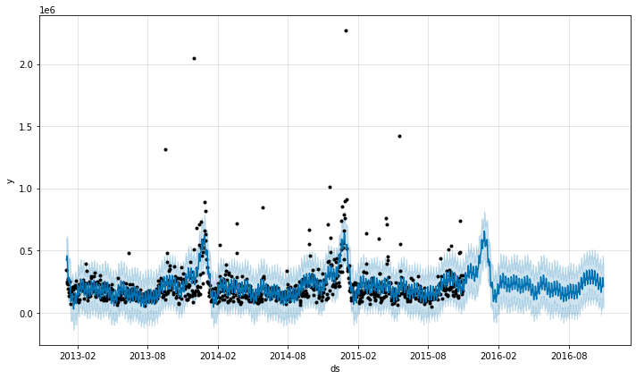

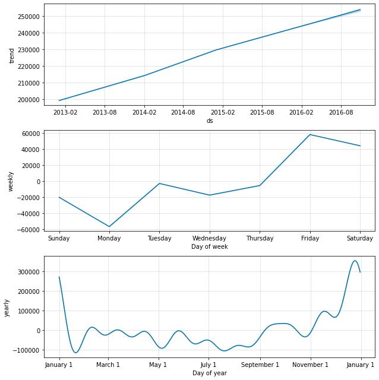

```python
# code here
fig = model_25.plot(forecast_25)
fig2 = model_25.plot_components(forecast_25)
```

## Model Tuning

From https://www.timeanddate.com/holidays/russia/2016 we know that in 2016, New Year and Christmas Holiday happened from 1 to 10 january

And from other sources we know that Russian celebrate christmas based on orthodox calendar which is in jan, so lets assume that sales on first week of january will be the highest in a year

### Country Holiday

```python
model_holiday_rus = Prophet()
model_holiday_rus.add_country_holidays(country_name='RU')
model_holiday_rus.fit(daily_total_rev)

model_holiday_rus.train_holiday_names
```

```
INFO:fbprophet:Disabling daily seasonality. Run prophet with daily_seasonality=True to override this.
```

```
0                    New Year's Day
1            Orthodox Christmas Day
2                     Christmas Day
3    Defender of the Fatherland Day
4         International Women's Day
5                 National Flag Day
6             Spring and Labour Day
7                       Victory Day
8                        Russia Day
9                         Unity Day
dtype: object
```

```python
# Reference: https://github.com/facebook/prophet/blob/master/python/fbprophet/hdays.py
from fbprophet import hdays
holidays_rus = hdays.Russia()
holidays_rus._populate(2013)
holidays_rus._populate(2014)
holidays_rus._populate(2015)
holidays_in_rus = pd.DataFrame([holidays_rus], index=['holiday']).T.rename_axis('ds').reset_index()
holidays_in_rus
```

|  | ds | holiday |
| --- | --- | --- |
| 0 | 2013-01-01 | New Year's Day |
| 1 | 2013-01-07 | Orthodox Christmas Day |
| 2 | 2013-12-25 | Christmas Day |
| 3 | 2013-02-23 | Defender of the Fatherland Day |
| 4 | 2013-03-08 | International Women's Day |
| 5 | 2013-08-22 | National Flag Day |
| 6 | 2013-05-01 | Spring and Labour Day |
| 7 | 2013-05-09 | Victory Day |
| 8 | 2013-06-12 | Russia Day |
| 9 | 2013-11-04 | Unity Day |
| 10 | 2014-01-01 | New Year's Day |
| 11 | 2014-01-07 | Orthodox Christmas Day |
| 12 | 2014-12-25 | Christmas Day |
| 13 | 2014-02-23 | Defender of the Fatherland Day |
| 14 | 2014-03-08 | International Women's Day |
| 15 | 2014-08-22 | National Flag Day |
| 16 | 2014-05-01 | Spring and Labour Day |
| 17 | 2014-05-09 | Victory Day |
| 18 | 2014-06-12 | Russia Day |
| 19 | 2014-11-04 | Unity Day |
| 20 | 2015-01-01 | New Year's Day |
| 21 | 2015-01-07 | Orthodox Christmas Day |
| 22 | 2015-12-25 | Christmas Day |
| 23 | 2015-02-23 | Defender of the Fatherland Day |
| 24 | 2015-03-08 | International Women's Day |
| 25 | 2015-08-22 | National Flag Day |
| 26 | 2015-05-01 | Spring and Labour Day |
| 27 | 2015-05-09 | Victory Day |
| 28 | 2015-06-12 | Russia Day |
| 29 | 2015-11-04 | Unity Day |

### Default Holiday

```python
holiday = pd.DataFrame({
    'holiday': 'new_year_eve',
    'ds': pd.to_datetime(['2013-12-31', '2014-12-31', # past date, historical data
                          '2015-12-31']), # future date, to be forecasted
    'lower_window': -4,
    'upper_window': 2})
holiday
```

|  | holiday | ds | lower_window | upper_window |
| --- | --- | --- | --- | --- |
| 0 | new_year_eve | 2013-12-31 | -4 | 2 |
| 1 | new_year_eve | 2014-12-31 | -4 | 2 |
| 2 | new_year_eve | 2015-12-31 | -4 | 2 |

```
INFO:fbprophet:Disabling daily seasonality. Run prophet with daily_seasonality=True to override this.
```

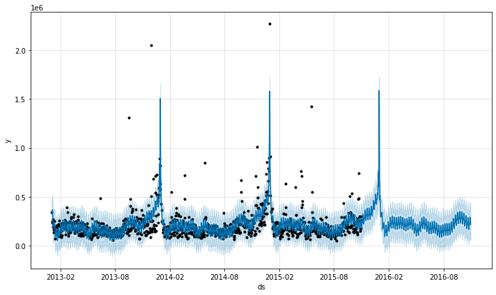

```python
# fitting model
model_holiday_rus = Prophet(holidays=holiday) #mendefinisikan hari libur
model_holiday_rus.fit(daily_total_rev) #melakukan fitting model yang sudah ditambah efek holiday

# forecasting
future = model_holiday_rus.make_future_dataframe(periods=365, freq='D') #membuat time window
forecast = model_holiday_rus.predict(future)

# visualize
fig = model_holiday_rus.plot(forecast)
```

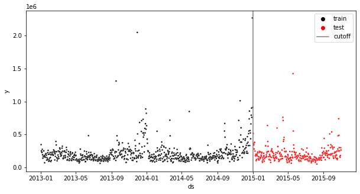

```python
# code here
cutoff = pd.to_datetime('2015-01-01')
daily_total_rev['type'] = daily_total_rev['ds'].apply(
    lambda date: 'train' if date < cutoff else 'test')

plt.figure(figsize=(10, 5))
sns.scatterplot(x='ds', y='y', hue='type', s=7,
                palette=['black', 'red'],
                data=daily_total_rev)
plt.axvline(x=cutoff, color='gray', label='cutoff')
plt.legend()
plt.show()
```

```python
#Split data train and test
train = daily_total_rev[daily_total_rev['ds'] < cutoff] # sebagai data yang akan dilatih
test = daily_total_rev[daily_total_rev['ds'] >= cutoff] # data unseen (dari visualisasi titik2 berwarna merah)
```

```python
# fitting model
model_final = Prophet(
    holidays=holiday, # holiday effect
    yearly_seasonality=True)
model_final.add_seasonality(name='monthly', period=30.5, fourier_order=5) # add monthly seasonality
model_final.fit(train)
```

```
INFO:fbprophet:Disabling daily seasonality. Run prophet with daily_seasonality=True to override this.
```

```
<fbprophet.forecaster.Prophet at 0x1e2c86ca8e0>
```

```python
# forecasting
future_final = model_final.make_future_dataframe(periods=303, freq='D') # 303 days (test size) -> adalah data dari 01 Jan 2015 - 31 Oct 2015
forecast_final = model_final.predict(future_final) #melakukan prediksi terhadap data test
```

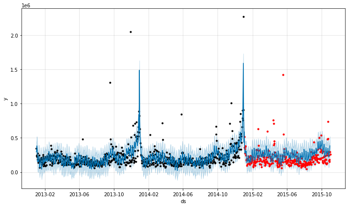

```python
# visualize
fig = model_final.plot(forecast_final)
plt.scatter(x=test['ds'], y=test['y'], s=10, color='red')
plt.show()
```

## Evaluation

```python
forecast_final
```

|  | ds | trend | yhat_lower | yhat_upper | trend_lower | trend_upper | additive_terms | additive_terms_lower | additive_terms_upper | holidays | ... | weekly | weekly_lower | weekly_upper | yearly | yearly_lower | yearly_upper | multiplicative_terms | multiplicative_terms_lower | multiplicative_terms_upper | yhat |
| --- | --- | --- | --- | --- | --- | --- | --- | --- | --- | --- | --- | --- | --- | --- | --- | --- | --- | --- | --- | --- | --- |
| 0 | 2013-01-02 | 200710.113233 | 159544.390872 | 439166.253265 | 200710.113233 | 200710.113233 | 93869.855975 | 93869.855975 | 93869.855975 | 0.0 | ... | -25746.192468 | -25746.192468 | -25746.192468 | 146986.533130 | 146986.533130 | 146986.533130 | 0.0 | 0.0 | 0.0 | 294579.969208 |
| 1 | 2013-01-03 | 200711.892320 | 177430.414550 | 460650.754638 | 200711.892320 | 200711.892320 | 118412.718670 | 118412.718670 | 118412.718670 | 0.0 | ... | 1412.629911 | 1412.629911 | 1412.629911 | 128432.507781 | 128432.507781 | 128432.507781 | 0.0 | 0.0 | 0.0 | 319124.610990 |
| 2 | 2013-01-04 | 200713.671408 | 242443.695592 | 520332.932116 | 200713.671408 | 200713.671408 | 182880.557782 | 182880.557782 | 182880.557782 | 0.0 | ... | 70262.534906 | 70262.534906 | 70262.534906 | 109191.922855 | 109191.922855 | 109191.922855 | 0.0 | 0.0 | 0.0 | 383594.229190 |
| 3 | 2013-01-05 | 200715.450496 | 201573.626034 | 492343.390714 | 200715.450496 | 200715.450496 | 144617.560807 | 144617.560807 | 144617.560807 | 0.0 | ... | 52111.003842 | 52111.003842 | 52111.003842 | 89538.626704 | 89538.626704 | 89538.626704 | 0.0 | 0.0 | 0.0 | 345333.011303 |
| 4 | 2013-01-06 | 200717.229584 | 95779.117010 | 396231.047434 | 200717.229584 | 200717.229584 | 39657.506769 | 39657.506769 | 39657.506769 | 0.0 | ... | -16055.652766 | -16055.652766 | -16055.652766 | 69754.070794 | 69754.070794 | 69754.070794 | 0.0 | 0.0 | 0.0 | 240374.736352 |
| ... | ... | ... | ... | ... | ... | ... | ... | ... | ... | ... | ... | ... | ... | ... | ... | ... | ... | ... | ... | ... | ... |
| 1025 | 2015-10-26 | 319932.874431 | 68761.750127 | 356536.511838 | 311170.434958 | 329613.333953 | -101357.944788 | -101357.944788 | -101357.944788 | 0.0 | ... | -64360.671926 | -64360.671926 | -64360.671926 | -44928.963535 | -44928.963535 | -44928.963535 | 0.0 | 0.0 | 0.0 | 218574.929644 |
| 1026 | 2015-10-27 | 320167.514542 | 129000.961216 | 417840.494772 | 311358.987281 | 329888.962484 | -46769.432747 | -46769.432747 | -46769.432747 | 0.0 | ... | -17623.651498 | -17623.651498 | -17623.651498 | -43296.649531 | -43296.649531 | -43296.649531 | 0.0 | 0.0 | 0.0 | 273398.081795 |
| 1027 | 2015-10-28 | 320402.154652 | 129561.626035 | 413401.917144 | 311550.348173 | 330120.512407 | -49457.413042 | -49457.413042 | -49457.413042 | 0.0 | ... | -25746.192468 | -25746.192468 | -25746.192468 | -40749.322044 | -40749.322044 | -40749.322044 | 0.0 | 0.0 | 0.0 | 270944.741610 |
| 1028 | 2015-10-29 | 320636.794762 | 163704.260401 | 454564.363276 | 311741.709066 | 330375.940709 | -15231.671485 | -15231.671485 | -15231.671485 | 0.0 | ... | 1412.629911 | 1412.629911 | 1412.629911 | -37309.302126 | -37309.302126 | -37309.302126 | 0.0 | 0.0 | 0.0 | 305405.123277 |
| 1029 | 2015-10-30 | 320871.434873 | 251537.159781 | 521413.038031 | 311933.130302 | 330669.675554 | 64817.293504 | 64817.293504 | 64817.293504 | 0.0 | ... | 70262.534906 | 70262.534906 | 70262.534906 | -33015.339470 | -33015.339470 | -33015.339470 | 0.0 | 0.0 | 0.0 | 385688.728377 |

1030 rows × 28 columns

Data Train Error Check

```python
from sklearn.metrics import mean_absolute_percentage_error

forecast_train = forecast_final[forecast_final['ds'] < cutoff]
forecast_train.head(2)
```

|  | ds | trend | yhat_lower | yhat_upper | trend_lower | trend_upper | additive_terms | additive_terms_lower | additive_terms_upper | holidays | ... | weekly | weekly_lower | weekly_upper | yearly | yearly_lower | yearly_upper | multiplicative_terms | multiplicative_terms_lower | multiplicative_terms_upper | yhat |
| --- | --- | --- | --- | --- | --- | --- | --- | --- | --- | --- | --- | --- | --- | --- | --- | --- | --- | --- | --- | --- | --- |
| 0 | 2013-01-02 | 200710.113233 | 159544.390872 | 439166.253265 | 200710.113233 | 200710.113233 | 93869.855975 | 93869.855975 | 93869.855975 | 0.0 | ... | -25746.192468 | -25746.192468 | -25746.192468 | 146986.533130 | 146986.533130 | 146986.533130 | 0.0 | 0.0 | 0.0 | 294579.969208 |
| 1 | 2013-01-03 | 200711.892320 | 177430.414550 | 460650.754638 | 200711.892320 | 200711.892320 | 118412.718670 | 118412.718670 | 118412.718670 | 0.0 | ... | 1412.629911 | 1412.629911 | 1412.629911 | 128432.507781 | 128432.507781 | 128432.507781 | 0.0 | 0.0 | 0.0 | 319124.610990 |

2 rows × 28 columns

```python
train_mape = mean_absolute_percentage_error(y_true=train['y'],
                                     y_pred=forecast_train['yhat'])
train_mape
```

```
0.28916917808618675
```

```python
forecast_test = forecast_final[forecast_final['ds'] >= cutoff]
forecast_test.head(2)
```

|  | ds | trend | yhat_lower | yhat_upper | trend_lower | trend_upper | additive_terms | additive_terms_lower | additive_terms_upper | holidays | ... | weekly | weekly_lower | weekly_upper | yearly | yearly_lower | yearly_upper | multiplicative_terms | multiplicative_terms_lower | multiplicative_terms_upper | yhat |
| --- | --- | --- | --- | --- | --- | --- | --- | --- | --- | --- | --- | --- | --- | --- | --- | --- | --- | --- | --- | --- | --- |
| 727 | 2015-01-01 | 250010.121569 | 290410.725629 | 586052.969610 | 250010.121569 | 250010.121569 | 185760.562061 | 185760.562061 | 185760.562061 | 0.000000 | ... | 1412.629911 | 1412.629911 | 1412.629911 | 172964.931424 | 172964.931424 | 172964.931424 | 0.0 | 0.0 | 0.0 | 435770.683630 |
| 728 | 2015-01-02 | 250244.761679 | 444267.420113 | 743255.110827 | 250244.761679 | 250244.761679 | 338119.946656 | 338119.946656 | 338119.946656 | 124810.279493 | ... | 70262.534906 | 70262.534906 | 70262.534906 | 155923.962280 | 155923.962280 | 155923.962280 | 0.0 | 0.0 | 0.0 | 588364.708335 |

2 rows × 28 columns

```python
test_mape = mean_absolute_percentage_error(y_true=test['y'],
                                     y_pred=forecast_test['yhat'])
test_mape
```

```
0.628312821856566
```

From the results, it shows MAPE train around 29% and MAPE test around 62% which is still quite high (or bad), i think it would be a good move if we do some further tuning.

## Cross Validation

```python
from fbprophet.diagnostics import cross_validation
df_cv = cross_validation(model_holiday_rus, initial='730 days', horizon='30 days', period='30 days')
df_cv
```

```
INFO:fbprophet:Making 10 forecasts with cutoffs between 2015-01-04 00:00:00 and 2015-10-01 00:00:00
```

[output not shown]

[output cut: 20 more lines]

|  | ds | yhat | yhat_lower | yhat_upper | y | cutoff |
| --- | --- | --- | --- | --- | --- | --- |
| 0 | 2015-01-05 | 277273.606118 | 123774.740251 | 429203.199141 | 278645.0 | 2015-01-04 |
| 1 | 2015-01-06 | 304872.670027 | 159370.309259 | 461263.674692 | 374783.0 | 2015-01-04 |
| 2 | 2015-01-07 | 277966.463613 | 125673.781198 | 418014.074614 | 379984.0 | 2015-01-04 |
| 3 | 2015-01-08 | 287155.520617 | 130743.109009 | 434251.577257 | 246544.0 | 2015-01-04 |
| 4 | 2015-01-09 | 337318.494772 | 193685.340452 | 494637.861828 | 179392.0 | 2015-01-04 |
| ... | ... | ... | ... | ... | ... | ... |
| 295 | 2015-10-27 | 180436.148546 | 38014.164687 | 328267.257597 | 165969.0 | 2015-10-01 |
| 296 | 2015-10-28 | 173437.885441 | 26538.156867 | 329265.695606 | 152358.0 | 2015-10-01 |
| 297 | 2015-10-29 | 193397.588758 | 45595.599011 | 341486.552059 | 179331.0 | 2015-10-01 |
| 298 | 2015-10-30 | 258019.158325 | 119015.294253 | 401467.339379 | 297992.0 | 2015-10-01 |
| 299 | 2015-10-31 | 247615.018131 | 102240.127561 | 400110.030775 | 263524.0 | 2015-10-01 |

300 rows × 6 columns

```python
cv_mape = df_cv.groupby('cutoff').apply(
    lambda x: mean_absolute_percentage_error(y_true=x['y'],
                                     y_pred=x['yhat']))
cv_mape
```

```
cutoff
2015-01-04    0.348856
2015-02-03    0.534362
2015-03-05    0.446446
2015-04-04    0.251898
2015-05-04    0.321683
2015-06-03    0.431438
2015-07-03    0.413404
2015-08-02    0.433229
2015-09-01    0.337201
2015-10-01    0.359264
dtype: float64
```

```python
cv_mape.mean()
```

```
0.3877780779789091
```

## Hyperparameter Tuning

```python
model_tune1 = Prophet(
    holidays=holiday,
    changepoint_prior_scale=0.1,
    changepoint_range=0.1
)
model_tune1.fit(daily_total_rev)
```

```
INFO:fbprophet:Disabling daily seasonality. Run prophet with daily_seasonality=True to override this.
```

```
<fbprophet.forecaster.Prophet at 0x1e2c8b539a0>
```

```python
cv_tune = cross_validation(model_tune1, initial='730 days', horizon = '30 days', period='90 days')
cv_tune
```

```
INFO:fbprophet:Making 4 forecasts with cutoffs between 2015-01-04 00:00:00 and 2015-10-01 00:00:00
```

|  | ds | yhat | yhat_lower | yhat_upper | y | cutoff |
| --- | --- | --- | --- | --- | --- | --- |
| 0 | 2015-01-05 | 256965.221479 | 111260.734398 | 407517.979462 | 278645.0 | 2015-01-04 |
| 1 | 2015-01-06 | 284292.047495 | 134660.725996 | 438087.468561 | 374783.0 | 2015-01-04 |
| 2 | 2015-01-07 | 257241.237028 | 110800.242655 | 399841.921851 | 379984.0 | 2015-01-04 |
| 3 | 2015-01-08 | 265811.711955 | 111569.737880 | 412561.605429 | 246544.0 | 2015-01-04 |
| 4 | 2015-01-09 | 315778.623855 | 155248.642871 | 461223.556155 | 179392.0 | 2015-01-04 |
| ... | ... | ... | ... | ... | ... | ... |
| 115 | 2015-10-27 | 182179.276224 | 33725.367763 | 329023.691389 | 165969.0 | 2015-10-01 |
| 116 | 2015-10-28 | 175254.544371 | 29178.502418 | 319402.342022 | 152358.0 | 2015-10-01 |
| 117 | 2015-10-29 | 195176.525547 | 46228.290707 | 351200.136256 | 179331.0 | 2015-10-01 |
| 118 | 2015-10-30 | 259827.242967 | 100761.109709 | 412488.325063 | 297992.0 | 2015-10-01 |
| 119 | 2015-10-31 | 249401.077876 | 98791.580863 | 399140.691847 | 263524.0 | 2015-10-01 |

120 rows × 6 columns

```python
cv_mape_tune = cv_tune.groupby('cutoff').apply(
    lambda x: mean_absolute_percentage_error(y_true=x['y'],
                                     y_pred=x['yhat']))
cv_mape_tune
```

```
cutoff
2015-01-04    0.310511
2015-04-04    0.252755
2015-07-03    0.370609
2015-10-01    0.362798
dtype: float64
```

```python
cv_mape_tune.mean()
```

```
0.32416795056509945
```

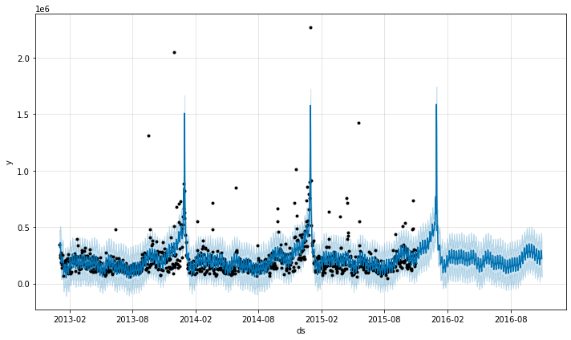

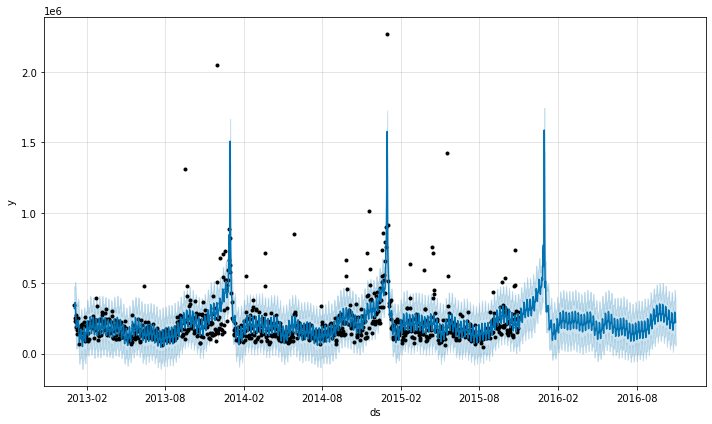

```python
# code here
future_tune = model_tune1.make_future_dataframe(periods=365, freq='D')
forecast_tune = model_tune1.predict(future_tune)

model_tune1.plot(forecast_tune)
```

## Conclusion

On Cross Validation Method and by implementing Hyperparameter Tuning, i use changepoint_prior_scale and changepoint_range as mentioned to get a lowest MAPE mean result. The result is (CV_MAPE_TUNE) 32.4% still quite high, i might choose additional method to lower the error.